# Prediction Assignment Writeup

M

4/11/2020

Using devices such as Jawbone Up, Nike FuelBand, and Fitbit, it is now possible to collect a large amount of data about personal activity relatively inexpensively. The aim of this project is to predict the manner in which participants perform a barbell lift. The data comes from http://groupware.les.inf.puc-rio.br/har wherein 6 participants were asked to perform the same set of exercises correctly and incorrectly with accelerometers placed on the belt, forearm, arm, and dumbell.

For the purpose of this project, the following steps would be followed:

1. Data Preprocessing
2. Exploratory Analysis
3. Prediction Model Selection
4. Predicting Test Set Output

## Data Preprocessing

```r
library(caret)

trainURL <- "http://d396qusza40orc.cloudfront.net/predmachlearn/pml-training.csv"
testURL <- "http://d396qusza40orc.cloudfront.net/predmachlearn/pml-testing.csv"
train <- read.csv(url(trainURL))
test <- read.csv(url(testURL))
label <- createDataPartition(train$classe, p = 0.7, list = FALSE)
train <- train[label, ]
test <- train[-label, ]
```

From among 160 variables present in the dataset, some variables have nearly zero variance whereas some contain a lot of NA terms which need to be excluded from the dataset. Moreover, other 5 variables used for identification can also be removed.

What we see is a lot of data with NA / empty values. Let’s remove those

```r
library(caret)
NZV <- nearZeroVar(train)
train <- train[ ,-NZV]
test <- test[ ,-NZV]
label <- apply(train, 2, function(x) mean(is.na(x))) > 0.95
train <- train[, -which(label, label == FALSE)]
test <- test[, -which(label, label == FALSE)]
train <- train[ , -(1:5)]
test <- test[ , -(1:5)]
```

As a result of the preprocessing steps, we were able to reduce 160 variables to 54.

## Exploratory Analysis

Now that we have cleaned the dataset off absolutely useless varibles, we shall look at the dependence of these variables on each other through a correlation plot.

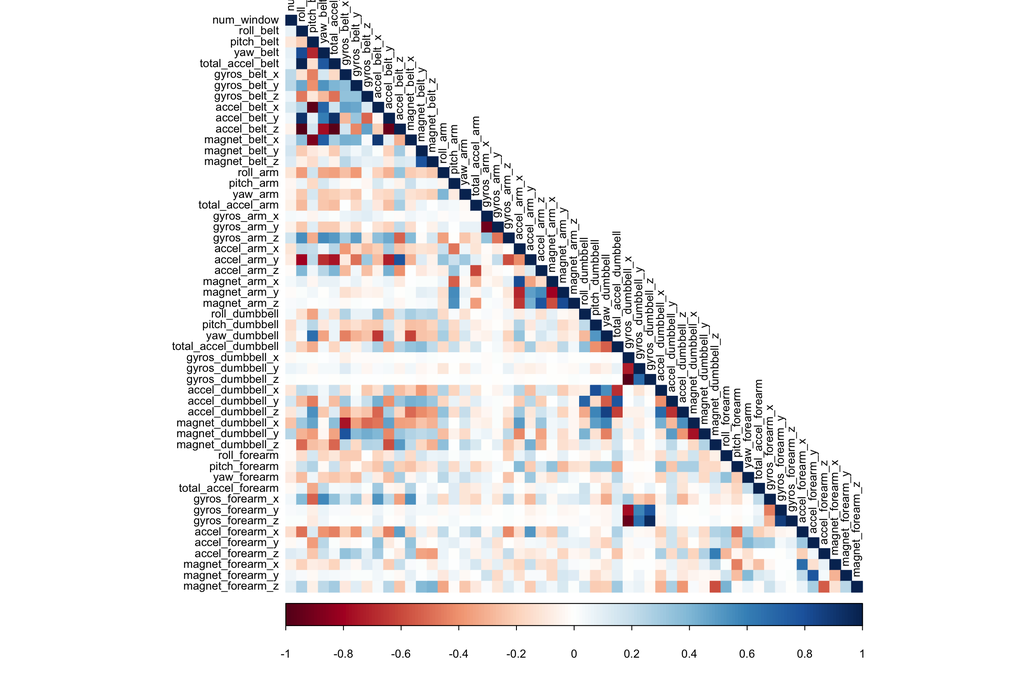

```r
library(corrplot)
corrMat <- cor(train[,-54])
corrplot(corrMat, method = "color", type = "lower", tl.cex = 0.8, tl.col = rgb(0,0,0))
```

In the plot above, darker gradient correspond to having high correlation. A Principal Component Analysis can be run to further reduce the dimension of our dataset.

## Prediction Model Selection

We will fit 3 methods to model our data. We will choose the better one after testing the best accuracy.

A confusion matrix plotted at the end of each model will help visualize the analysis better.

### Decision Tree

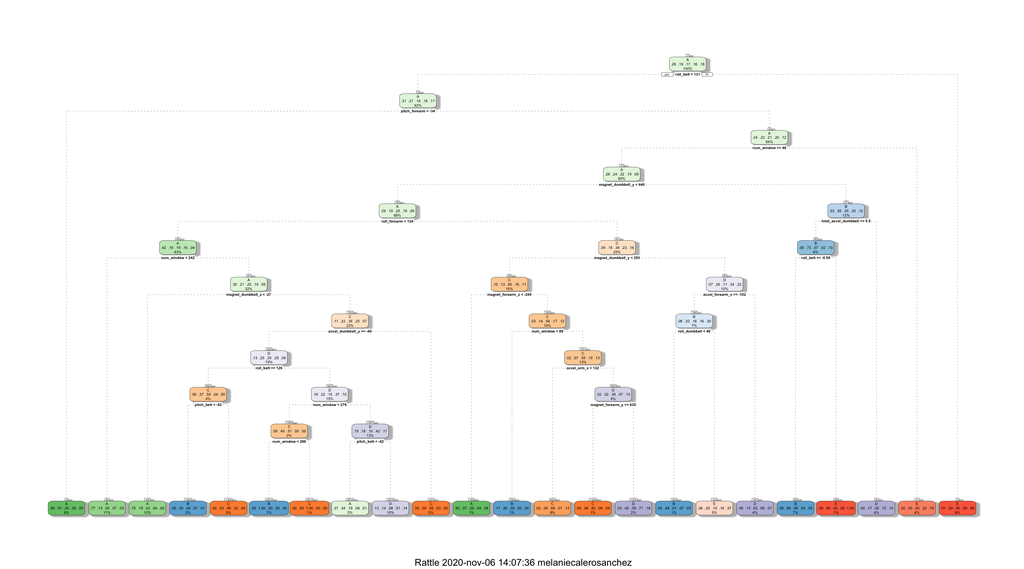

```r
library(rpart)
library(rpart.plot)
#install.packages("rattle")
library(rattle)
set.seed(13908)
modelDT <- rpart(classe ~ ., data = train, method = "class")
fancyRpartPlot(modelDT)
```

```r
predictDT <- predict(modelDT, test, type = "class")
#install.packages("e1071")
library(e1071)
confMatDT <- confusionMatrix(predictDT, test$classe)
confMatDT
```

```
## Confusion Matrix and Statistics
##
##           Reference
## Prediction    A    B    C    D    E
##          A 1079  176   30   65   19
##          B   19  402   29   18   10
##          C    8   58  570   42   47
##          D   69  103   62  473  101
##          E   13   37   39   62  591
##
## Overall Statistics
##
##                Accuracy : 0.7557
##                  95% CI : (0.7423, 0.7688)
##     No Information Rate : 0.2882
##     P-Value [Acc > NIR] : < 2.2e-16
##
##                   Kappa : 0.6893
##
##  Mcnemar's Test P-Value : < 2.2e-16
##
## Statistics by Class:
##
##                      Class: A Class: B Class: C Class: D Class: E
## Sensitivity            0.9082  0.51804   0.7808   0.7167   0.7695
## Specificity            0.9012  0.97729   0.9543   0.9032   0.9550
## Pos Pred Value         0.7882  0.84100   0.7862   0.5854   0.7965
## Neg Pred Value         0.9604  0.89737   0.9529   0.9436   0.9476
## Prevalence             0.2882  0.18826   0.1771   0.1601   0.1863
## Detection Rate         0.2618  0.09753   0.1383   0.1148   0.1434
## Detection Prevalence   0.3321  0.11596   0.1759   0.1960   0.1800
## Balanced Accuracy      0.9047  0.74766   0.8676   0.8100   0.8623
```

### Random Forest

```r
library(caret)
set.seed(13908)
control <- trainControl(method = "cv", number = 3, verboseIter=FALSE)
modelRF <- train(classe ~ ., data = train, method = "rf", trControl = control)
modelRF$finalModel
```

```
##
## Call:
##  randomForest(x = x, y = y, mtry = param$mtry)
##                Type of random forest: classification
##                      Number of trees: 500
## No. of variables tried at each split: 27
##
##         OOB estimate of  error rate: 0.19%
## Confusion matrix:
##      A    B    C    D    E  class.error
## A 3905    0    0    0    1 0.0002560164
## B    6 2649    3    0    0 0.0033860045
## C    0    5 2390    1    0 0.0025041736
## D    0    0    6 2245    1 0.0031083481
## E    0    0    0    3 2522 0.0011881188
```

```r
predictRF <- predict(modelRF, test)
confMatRF <- confusionMatrix(predictRF, test$classe)
confMatRF
```

```
## Confusion Matrix and Statistics
##
##           Reference
## Prediction    A    B    C    D    E
##          A 1188    0    0    0    0
##          B    0  776    0    0    0
##          C    0    0  730    0    0
##          D    0    0    0  660    0
##          E    0    0    0    0  768
##
## Overall Statistics
##
##                Accuracy : 1
##                  95% CI : (0.9991, 1)
##     No Information Rate : 0.2882
##     P-Value [Acc > NIR] : < 2.2e-16
##
##                   Kappa : 1
##
##  Mcnemar's Test P-Value : NA
##
## Statistics by Class:
##
##                      Class: A Class: B Class: C Class: D Class: E
## Sensitivity            1.0000   1.0000   1.0000   1.0000   1.0000
## Specificity            1.0000   1.0000   1.0000   1.0000   1.0000
## Pos Pred Value         1.0000   1.0000   1.0000   1.0000   1.0000
## Neg Pred Value         1.0000   1.0000   1.0000   1.0000   1.0000
## Prevalence             0.2882   0.1883   0.1771   0.1601   0.1863
## Detection Rate         0.2882   0.1883   0.1771   0.1601   0.1863
## Detection Prevalence   0.2882   0.1883   0.1771   0.1601   0.1863
## Balanced Accuracy      1.0000   1.0000   1.0000   1.0000   1.0000
```

### Generalized Boosted Model

```r
library(caret)
set.seed(13908)
control <- trainControl(method = "repeatedcv", number = 5, repeats = 1, verboseIter = FALSE)
modelGBM <- train(classe ~ ., data = train, trControl = control, method = "gbm", verbose = FALSE)
modelGBM$finalModel
```

```
## A gradient boosted model with multinomial loss function.
## 150 iterations were performed.
## There were 53 predictors of which 53 had non-zero influence.
```

```r
predictGBM <- predict(modelGBM, test)
confMatGBM <- confusionMatrix(predictGBM, test$classe)
confMatGBM
```

```
## Confusion Matrix and Statistics
##
##           Reference
## Prediction    A    B    C    D    E
##          A 1187    5    0    0    0
##          B    1  766    7    2    1
##          C    0    4  720    3    1
##          D    0    1    3  654    7
##          E    0    0    0    1  759
##
## Overall Statistics
##
##                Accuracy : 0.9913
##                  95% CI : (0.9879, 0.9939)
##     No Information Rate : 0.2882
##     P-Value [Acc > NIR] : < 2.2e-16
##
##                   Kappa : 0.9889
##
##  Mcnemar's Test P-Value : NA
##
## Statistics by Class:
##
##                      Class: A Class: B Class: C Class: D Class: E
## Sensitivity            0.9992   0.9871   0.9863   0.9909   0.9883
## Specificity            0.9983   0.9967   0.9976   0.9968   0.9997
## Pos Pred Value         0.9958   0.9858   0.9890   0.9835   0.9987
## Neg Pred Value         0.9997   0.9970   0.9971   0.9983   0.9973
## Prevalence             0.2882   0.1883   0.1771   0.1601   0.1863
## Detection Rate         0.2880   0.1858   0.1747   0.1587   0.1841
## Detection Prevalence   0.2892   0.1885   0.1766   0.1613   0.1844
## Balanced Accuracy      0.9987   0.9919   0.9920   0.9939   0.9940
```

As Random Forest offers the maximum accuracy of 100.00%. We could have a little problem of overfitting.We can note this when we have this perfect confusion matrix. We select the GBM Model.

```r
predictGBM <- predict(modelGBM, test)
#predictGBM
```

## Using Cross Validation

Using the tecnique of Cross Validation to prevent the overfitting.

#### Random forest

##### Model

```r
controlRf <- trainControl(method="cv", 5, allowParallel = TRUE)
modelRf <- train(classe ~ ., data=train, method="rf", trControl=controlRf, ntree=100)
#modelRf
```

##### Performance of the model on the test set

```r
predict_rf <- predict(modelRf, test)
confusionMatrix(test$classe, predict_rf)
```

```
## Confusion Matrix and Statistics
##
##           Reference
## Prediction    A    B    C    D    E
##          A 1188    0    0    0    0
##          B    0  776    0    0    0
##          C    0    0  730    0    0
##          D    0    0    0  660    0
##          E    0    0    0    0  768
##
## Overall Statistics
##
##                Accuracy : 1
##                  95% CI : (0.9991, 1)
##     No Information Rate : 0.2882
##     P-Value [Acc > NIR] : < 2.2e-16
##
##                   Kappa : 1
##
##  Mcnemar's Test P-Value : NA
##
## Statistics by Class:
##
##                      Class: A Class: B Class: C Class: D Class: E
## Sensitivity            1.0000   1.0000   1.0000   1.0000   1.0000
## Specificity            1.0000   1.0000   1.0000   1.0000   1.0000
## Pos Pred Value         1.0000   1.0000   1.0000   1.0000   1.0000
## Neg Pred Value         1.0000   1.0000   1.0000   1.0000   1.0000
## Prevalence             0.2882   0.1883   0.1771   0.1601   0.1863
## Detection Rate         0.2882   0.1883   0.1771   0.1601   0.1863
## Detection Prevalence   0.2882   0.1883   0.1771   0.1601   0.1863
## Balanced Accuracy      1.0000   1.0000   1.0000   1.0000   1.0000
```

Accurate model to classify **classe** feature. Maybe we have overfit.

#### XGBoost

```r
controlXGB <- trainControl(method="cv", 5, allowParallel = TRUE)
modelXGB <- train(classe ~ ., data=train, method="xgbTree", trControl=controlXGB)
```

```r
#modelXGB
```

##### Performance of the model on the test set

```r
predict_XGB <- predict(modelXGB, test)
confusionMatrix(test$classe, predict_XGB)
```

```
## Confusion Matrix and Statistics
##
##           Reference
## Prediction    A    B    C    D    E
##          A 1188    0    0    0    0
##          B    0  776    0    0    0
##          C    0    0  730    0    0
##          D    0    0    0  660    0
##          E    0    0    0    0  768
##
## Overall Statistics
##
##                Accuracy : 1
##                  95% CI : (0.9991, 1)
##     No Information Rate : 0.2882
##     P-Value [Acc > NIR] : < 2.2e-16
##
##                   Kappa : 1
##
##  Mcnemar's Test P-Value : NA
##
## Statistics by Class:
##
##                      Class: A Class: B Class: C Class: D Class: E
## Sensitivity            1.0000   1.0000   1.0000   1.0000   1.0000
## Specificity            1.0000   1.0000   1.0000   1.0000   1.0000
## Pos Pred Value         1.0000   1.0000   1.0000   1.0000   1.0000
## Neg Pred Value         1.0000   1.0000   1.0000   1.0000   1.0000
## Prevalence             0.2882   0.1883   0.1771   0.1601   0.1863
## Detection Rate         0.2882   0.1883   0.1771   0.1601   0.1863
## Detection Prevalence   0.2882   0.1883   0.1771   0.1601   0.1863
## Balanced Accuracy      1.0000   1.0000   1.0000   1.0000   1.0000
```

### Compare models

```r
# collect resamples
model_results <- resamples(list(RF=modelRf, XGB=modelXGB))
# summarize the distributions
summary(model_results)
```

```
##
## Call:
## summary.resamples(object = model_results)
##
## Models: RF, XGB
## Number of resamples: 5
##
## Accuracy
##          Min.   1st Qu.    Median      Mean   3rd Qu.      Max. NA's
## RF  0.9959956 0.9967237 0.9974527 0.9970881 0.9974527 0.9978158    0
## XGB 0.9985439 0.9992719 0.9996360 0.9994176 0.9996361 1.0000000    0
##
## Kappa
##          Min.   1st Qu.    Median      Mean   3rd Qu.      Max. NA's
## RF  0.9949341 0.9958558 0.9967778 0.9963165 0.9967778 0.9972372    0
## XGB 0.9981582 0.9990790 0.9995396 0.9992633 0.9995398 1.0000000    0
```

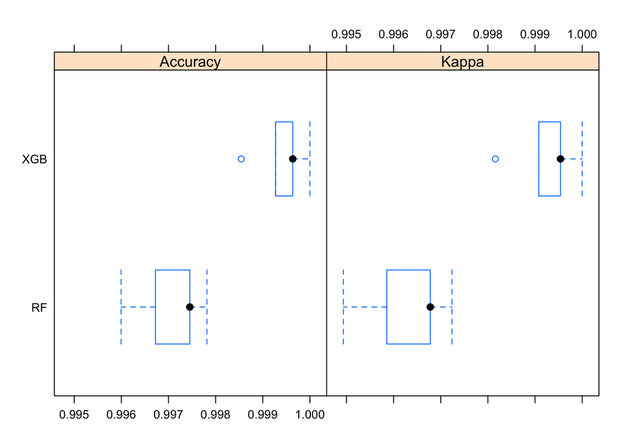

```r
# boxplots of results
bwplot(model_results)
```

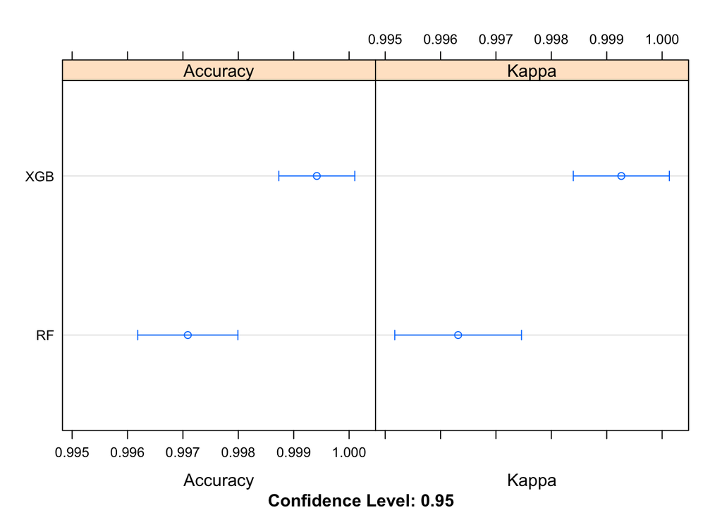

```r
# dot plots of results
dotplot(model_results)
```